# Harmful Weather Events in the U.S. (1950-2011)

Pedro Córdova

2023-04-02

## Synopsis

This study was created as part of the “Reproducible Research” JHU’s course.  
The goal of this assignment is to explore the NOAA Storm Database and answer some basic questions about severe weather events during the 1950-2011 period. Additionally, the code for the entire analysis must be shown.  
It was found that:

- Most harmful effects in terms of human casualties were those caused by tornadoes (both, fatalities and injuries)
- Most harmful effects in terms of property damage were caused by floods
- Most harmful effects in terms of crop loss were caused by drought

Finally choropleth maps shows that the most affected U.S. state in terms of human casualties was Texas and the most affected state in terms of material loss was California.

## Data Processing

#### Downloading and Reading Data

First, let’s do some “administrative”, but necessary, preparation work.  
We are going to do some configuration, download and sub-set the data file, load required libraries, etc.

```r
options(scipen=999) # Turn off scientific notation globally

## Load required libraries
library(knitr)
library(data.table)
library(DT)
library(ggplot2)
library(fiftystater)
library(patchwork)
library(ggsn) # For scale bar
library(scales) # For currency format

## Create directory to store the file
if(!dir.exists("Data")) {dir.create("Data")}

## Download data file
if(!file.exists("./Data/stormData.csv.bz2")) {
    download.file("https://d396qusza40orc.cloudfront.net/repdata%2Fdata%2FStormData.csv.bz2",
                  "./Data/stormData.csv.bz2", method = "curl")
}

## Read data file
stormData <- fread("./Data/stormData.csv.bz2",
                               select = c(7,8,23:28),        # Select just relevant columns
                               col.names = c("state",        # Rename columns
                                             "event",
                                             "fatalities",
                                             "injuries",
                                             "propDamage",
                                             "propUnits",
                                             "cropDamage",
                                             "cropUnits"))
```

Now, we have all the relevant data loaded into our workspace. How its structure looks like?

```r
str(stormData)
```

```
## Classes 'data.table' and 'data.frame':   902297 obs. of  8 variables:
##  $ state     : chr  "AL" "AL" "AL" "AL" ...
##  $ event     : chr  "TORNADO" "TORNADO" "TORNADO" "TORNADO" ...
##  $ fatalities: num  0 0 0 0 0 0 0 0 1 0 ...
##  $ injuries  : num  15 0 2 2 2 6 1 0 14 0 ...
##  $ propDamage: num  25 2.5 25 2.5 2.5 2.5 2.5 2.5 25 25 ...
##  $ propUnits : chr  "K" "K" "K" "K" ...
##  $ cropDamage: num  0 0 0 0 0 0 0 0 0 0 ...
##  $ cropUnits : chr  "" "" "" "" ...
##  - attr(*, ".internal.selfref")=<externalptr>
```

#### Cleaning Data

What about data integrity/quality?  
Let’s check for `NA` values:

```r
cat('- **There exists**', paste0("**",sum(is.na(stormData)),"**"),'**NA values**<br>')
```

- **There exists** **0** **NA values**

Nice!

Time to take a look at relevant data to evaluate material losses.

As reported in this file from the National Weather Service Storm Data Documentation:

> *Alphabetical characters used to signify magnitude include “K” for thousands, “M” for millions, and “B” for billions.*

Those characters are contained in `propUnits` and `cropUnits` columns. Let’s see what there is inside:

```r
unique(stormData$propUnits)
```

```
##  [1] "K" "M" ""  "B" "m" "+" "0" "5" "6" "?" "4" "2" "3" "h" "7" "H" "-" "1" "8"
```

```r
unique(stormData$cropUnits)
```

```
## [1] ""  "M" "K" "m" "B" "?" "0" "k" "2"
```

As we can see, in both columns there is a lot of garbage that does not correspond to the required characters. Furthermore, we need the characters to be translated into numerical values in order to calculate the amount of material loss (e.g. `propDamage` values multiplied by `propUnits` values).  
There are other issues concerning to data quality but, for the sake of brevity, only this problem will be considered.

To start, let’s assume that lower case `b`, `m` and `k` where introduced instead of its upper case counterparts.

First, let’s create two columns filled with zeroes as a future containers for our units (B, M, K) as numeric values (1e+9, 1e+6, 1e+3):

```r
stormData[, `:=`(pUnits = 0, cUnits = 0)]
```

Second, let’s translate characters to numeric values and assign them to their corresponding positions in the recently created columns:

```r
stormData[propUnits %in% c("K","k"), "pUnits" := 1e+3
          ][propUnits %in% c("M","m"), "pUnits" := 1e+6
            ][propUnits %in% c("B","b"), "pUnits" := 1e+9]

stormData[cropUnits %in% c("K","k"), "cUnits" := 1e+3
          ][cropUnits %in% c("M","m"), "cUnits" := 1e+6
            ][cropUnits %in% c("B","b"), "cUnits" := 1e+9]
```

Now we are ready to do the math!

We are going to calculate the monetary value of property and crop losses and tabulate the data:

```r
stormData[, `:=`(propLoss = propDamage*pUnits, cropLoss = cropDamage*cUnits)]

cost <- stormData[, .(fatalities = sum(fatalities),
                      injuries = sum(injuries),
                      propLoss = sum(propLoss),
                      cropLoss = sum(cropLoss)),
                      by = event
                  ]

cost <- cost[fatalities != 0 | injuries != 0 | propLoss != 0 | cropLoss != 0] # Delete rows containing
                                                                              # only zeroes
```

```r
## Generate table
t <- cost[order(-fatalities,-injuries,-propLoss,-cropLoss)] %>%
     datatable(colnames = c("Event", "Fatalities", "Injuries", "Property Loss", "Crop Loss"),
               caption = htmltools::tags$caption(
               style = 'caption-side: bottom; text-align: left;', "Data source: NOAA"),
               rownames = FALSE,
               options = list(dom = 'ftp')) %>%
    formatCurrency(c(4, 5), digits = 0)
```

#### Table: Total Weather Events in the U.S., from Deadliest to less Harmful (1950-2011)

| Event | Fatalities | Injuries | Property Loss | Crop Loss |
| --- | --- | --- | --- | --- |
| TORNADO | 5633 | 91346 | 56937160480 | 414953110 |
| EXCESSIVE HEAT | 1903 | 6525 | 7753700 | 492402000 |
| FLASH FLOOD | 978 | 1777 | 16140811510 | 1421317100 |
| HEAT | 937 | 2100 | 1797000 | 401461500 |
| LIGHTNING | 816 | 5230 | 928659280 | 12092090 |
| TSTM WIND | 504 | 6957 | 4484928440 | 554007350 |
| FLOOD | 470 | 6789 | 144657709800 | 5661968450 |
| RIP CURRENT | 368 | 232 | 1000 | 0 |
| HIGH WIND | 248 | 1137 | 5270046260 | 638571300 |
| AVALANCHE | 224 | 170 | 3721800 | 0 |

[output cut: 473 more lines]

In the table above you can search for your favourite natural disaster and see the human and material effects caused by it.

## Results

#### Most harmful weather events to population health

```r
## Detect fatalities
cat("- **Deadliest weather event:", paste0(cost[which.max(cost$fatalities),event],"."),
    "<br>It accounts for", cost[,max(fatalities)],
    "fatalities between 1950 and 2011.**")
```

- Deadliest weather event: TORNADO.  
  It accounts for 5633 fatalities between 1950 and 2011.

```r
## Detect injuries
cat("- **Weather event causing more injuries in the same period (1950-2011):",
    paste0(cost[which.max(cost$injuries),event],"."), "<br>It accounts for",
    cost[,max(injuries)], "injuries.**")
```

- Weather event causing more injuries in the same period (1950-2011): TORNADO.  
  It accounts for 91346 injuries.

#### Most harmful weather events to property and crops

```r
## Detect fatalities
cat("- **Most harmful weather event over property:", paste0(cost[which.max(cost$propLoss),event],"."),
    "<br>It accounts for", dollar_format()(cost[,max(propLoss)]), "total loss between 1950 and 2011.**")
```

- Most harmful weather event over property: FLOOD.  
  It accounts for $144,657,709,800 total loss between 1950 and 2011.

```r
## Detect injuries
cat("- **Weather event causing more crop losses in the same period (1950-2011):",
    paste0(cost[which.max(cost$cropLoss),event],"."), "<br>It accounts for",
    dollar_format()(cost[,max(cropLoss)]), "total loss.**")
```

- Weather event causing more crop losses in the same period (1950-2011): DROUGHT.  
  It accounts for $13,972,566,000 total loss.

#### Distribution of the harmful weather effects across the U.S. geography

To visualise the distribution of the harmful weather effects across the U.S. geography we need to do some additional data wrangling:

```r
## Download file containing coordinates
if(!file.exists("./Data/stormData.csv.bz2")) {
    download.file("https://raw.githubusercontent.com/pcordova/Weather-Events/main/statesCoord.csv",
              "./Data/statesCoord.csv", method = "curl")
}

## Generate a file to be plotted
states <- fread("./Data/statesCoord.csv", col.names = c("state","location","lat","lon"))

effects <- stormData[, .(fatalities = sum(fatalities),
                      injuries = sum(injuries),
                      propLoss = sum(propLoss),
                      cropLoss = sum(cropLoss)),
                      by = state
                  ]
mapdata <- effects[state %in% states$state]

setorder(mapdata,state)
setorder(states,state)

mapdata <- cbind(mapdata,states[,.(location,lat,lon)])
mapdata[,`:=` (location = tolower(location))]
mapdata <- mapdata[,.(state,
                      location,
                      casualties = fatalities+injuries,
                      losses = round((propLoss+cropLoss)/1e+6, digits = 1),
                      lat,
                      lon)]

## We need a theme for our maps
maptheme <- theme(text = element_text(family = 'Avenir', colour = '#092733'),
                 panel.background = element_rect(fill = '#DDEDF3'),
                 plot.title = element_text(size = 12, hjust = 0.5),
                 plot.subtitle = element_text(size = 10, hjust = 0.5),
                 legend.position = "bottom"
                 )
```

Data is ready, time to create a couple of (choropleth) maps:

```r
## Generate a map showing human casualties (fatalities + injuries)
c <- ggplot(mapdata, aes(map_id = location)) +
     geom_map(aes(fill = casualties),  color= "white", map = fifty_states) +
     expand_limits(x = fifty_states$long, y = fifty_states$lat) +
     coord_map() +
     labs(title = "Total Casualties Caused by Extreme Weather Events in the U.S.",
          subtitle = "1950-2011",
          caption = "Data source: NOAA") +
     geom_text(data = mapdata,  size=2, colour="white",
          aes(x = lon, y = lat, label = paste(state, casualties, sep = '\n'))) +
     scale_x_continuous(breaks = NULL) +
     scale_y_continuous(breaks = NULL) +
     labs(x = "", y = "") +
     labs(fill = "Casualties")+
     scale_fill_gradient(low = "#546E7A", high = "#A03232",
                         guide = guide_colourbar(barwidth = 25, barheight = 0.4,
                                                 title.position = "top")) + #put legend title on top of legend
     maptheme +
     fifty_states_inset_boxes()

## Generate a map showing material damage (property + crops)
l <- ggplot(mapdata, aes(map_id = location)) +
     geom_map(aes(fill = losses),  color= "white", map = fifty_states) +
     expand_limits(x = fifty_states$long, y = fifty_states$lat) +
     coord_map() +
     labs(title = "Total Financial Loss Caused by Extreme Weather Events in the U.S.",
          subtitle = "1950-2011",
          caption = "Data source: NOAA") +
     geom_text(data = mapdata,  size=2, colour="white",
          aes(x = lon, y = lat, label = paste(state, losses, sep = '\n'))) +
     scale_x_continuous(breaks = NULL) +
     scale_y_continuous(breaks = NULL) +
     labs(x = "", y = "") +
     labs(fill = "Loss Amount (USD Millions)")+
     scale_fill_gradient(low = "#546E7A", high = "#A03232",
                         guide = guide_colourbar(barwidth = 25, barheight = 0.4,
                                                 title.position = "top")) + #put legend title on top of legend
     maptheme +
     fifty_states_inset_boxes()
```

Finally, let’s do a couple of data visualisations:

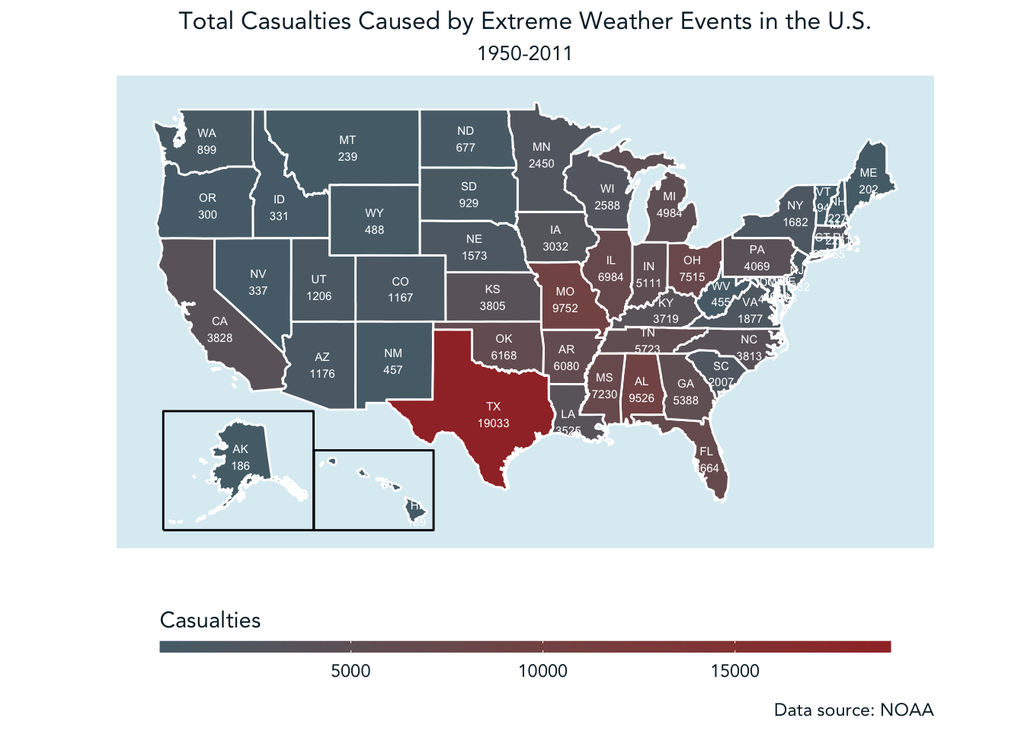

```r
c
```

**Stay away from Texas during weather events!**

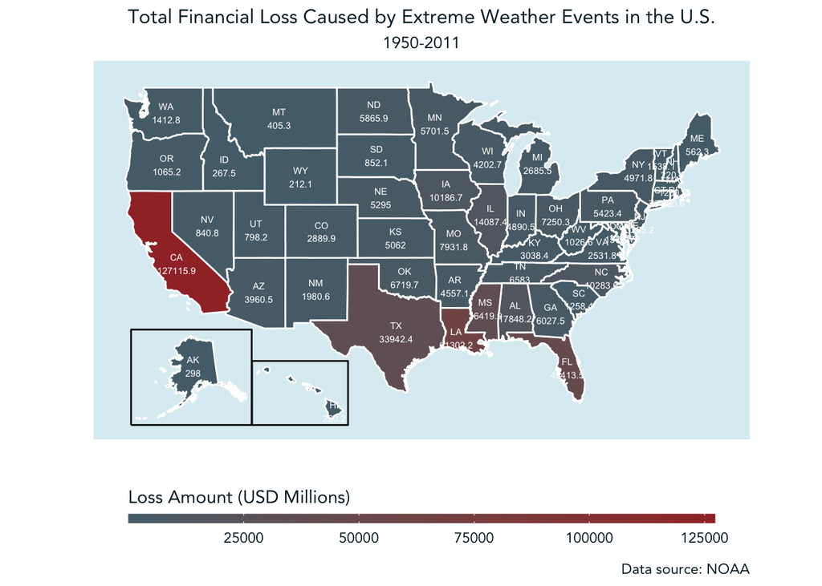

```r
l
```

**Hire a reliable insurance company if you live in California!**